# Should We Trust Election Polls?

Investigation of the Turkish Case — Updated and Extended Edition (2011–2024)

Isin Acun

July 2026

## About this update

The original version of this study was written as a bachelor’s project and examined seven Turkish elections between 2011 and 2019, asking a simple question: **can we trust the election forecasts of Turkish polling firms?** The idea goes back to [Erol Taymaz’s November 2015 blog post *“Seçim Anketleri Ne Kadar Güvenilir?”*](https://users.metu.edu.tr/etaymaz/secim-tahmin.html) (METU), which analysed the polls of the June and November 2015 general elections with regression models and showed that the November 2015 polls failed collectively and inexplicably. This update owes its central question — and its method of reading forecast errors against the clock — to that post, and to Prof. Taymaz’s teaching.

Since the original study closed with the 2019 local elections, Turkey has voted three more times: the **May 2023 presidential election** (two rounds), the **May 2023 parliamentary election**, and the **March 2024 local elections**. Those races are close to a natural experiment for the original study’s conclusions, and this edition puts them to the test. All new data were re-scraped from Wikipedia’s opinion-polling pages and analysed in R, exactly in the spirit of the original workflow: 284 campaign polls (plus 56 hypothetical runoff head-to-heads, shown separately), 1249 party-level estimates, 51 polling firms.

Throughout, the **estimation error** of a poll is defined as *poll value − official result*, in percentage points: a positive error means the firm overestimated a party or candidate, and a credible forecaster’s errors should shrink toward the zero line as election day approaches.

## What the 2011–2019 study found

The original analysis of a referendum, four general and two local elections led to three conclusions. First, in most races the errors of most firms did drift toward zero as the election approached — with the dramatic exception of November 2015, where the industry as a whole diverged from the result it was supposedly converging on (the election Taymaz’s post dissected). Second, even excluding November 2015 there was **no sign that forecasting accuracy improved over the decade** — experience and technology did not buy smaller errors. Third, two firms showed **persistent, mirror-image deviations**: ORC’s estimates for AKP ran consistently above the result while its CHP estimates ran below, and AKAM’s showed exactly the opposite pattern. The study suggested — cautiously, given the small number of elections — that ORC might be biased toward AKP and AKAM toward CHP, and closed by noting that “with the further observations in the upcoming elections, analyses are expected to improve and support our claim.”

Two summary figures from the 2019 edition, kept here for the record:

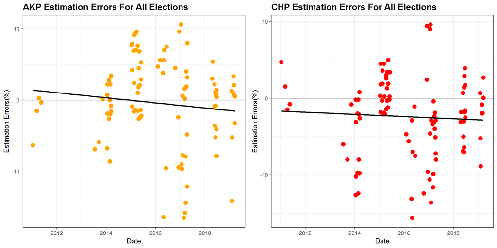

From the 2019 edition: AKP and CHP estimation errors across all 2011–2019 elections. No trend toward smaller errors.

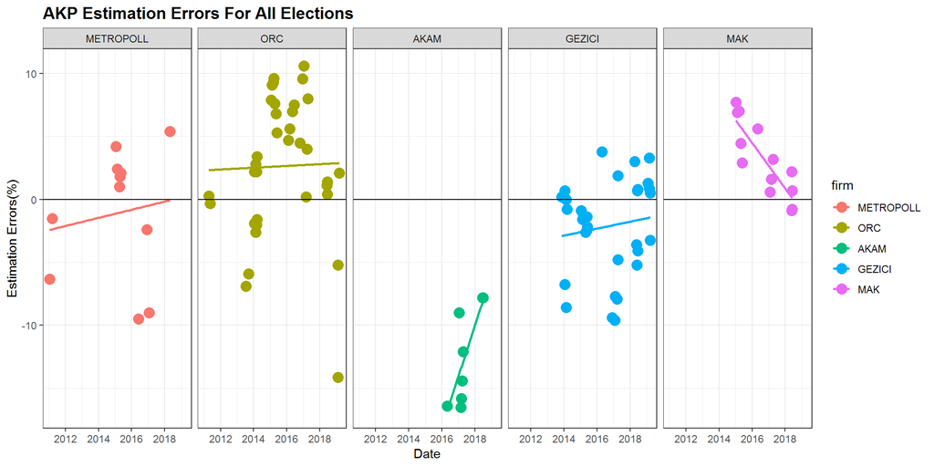

From the 2019 edition: AKP errors by firm. ORC persistently above zero, AKAM persistently below — the original bias hypothesis.

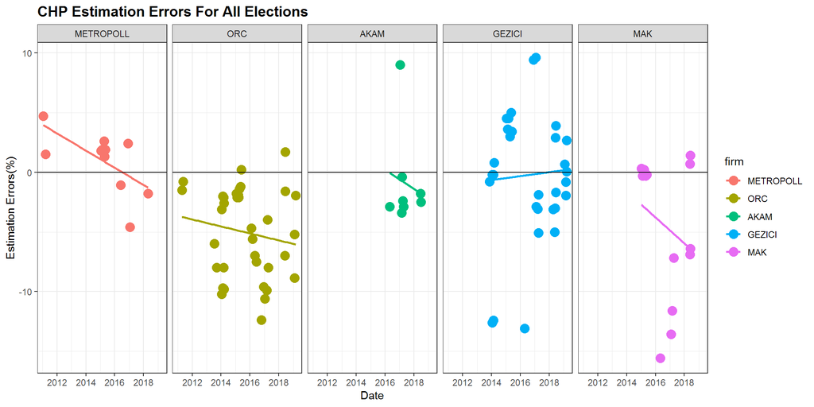

From the 2019 edition: CHP errors by firm — the mirror image (ORC below zero, AKAM near/above).

## The 2023–2024 elections at a glance

[output not shown]

## The first round of 2023: a collective miss

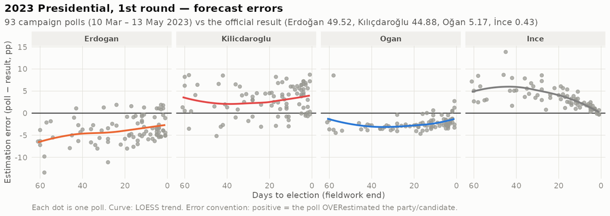

The parliamentary vote, polled by the same firms on the same fieldwork, tells a subtler story: the industry had **AKP almost exactly right** (mean error −0.2) and the collapse of accuracy was concentrated in the junior partners — MHP was underestimated by 3.0 points on average (polls gave it ~7%, it won 10.05%), YRP by 1.5, while CHP (+2.5) and İYİ (+1.4) were flattered. The presidential miss was therefore not a simple “shy AKP voter” story: pollsters found the AKP vote but systematically missed where the rest of the government bloc’s votes would go.

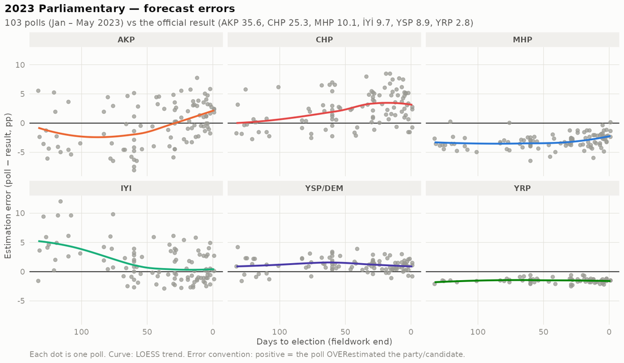

### The runoff: a partial redemption

Two weeks later the same industry polled the runoff far better: the mean error on Erdoğan fell from −3.8 to **−0.7**, and 7 of the 11 campaign polls put him ahead. Interestingly, the *hypothetical* Erdoğan–Kılıçdaroğlu head-to-head polls taken in the months before the first round carried the same ~4-point anti-Erdoğan skew — the correction happened only after reality had intervened once.

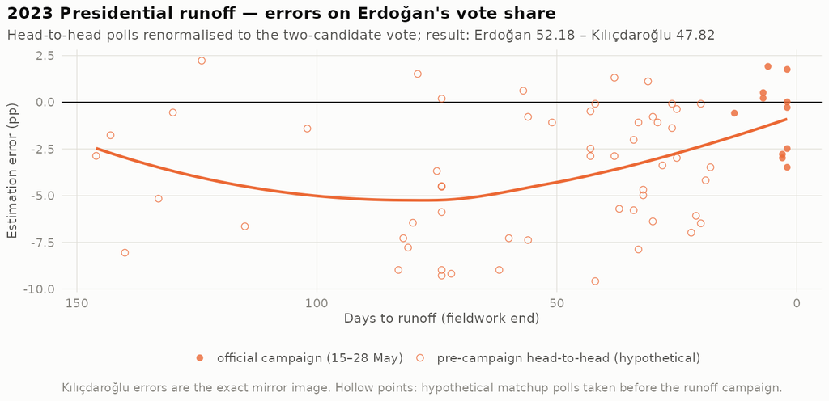

## 2024: the miss flips sides

If 2023 could be read as pro-opposition wishfulness, 2024 destroys that reading. In Istanbul and Ankara the polls **understated the opposition** on a scale the 2011–2019 dataset never saw: İmamoğlu’s vote was missed by **−7.7 points on average** (even after renormalising polls that reported an explicit undecided share) and Yavaş’s by **−9.3**, while their AKP rivals were estimated roughly correctly. Every one of the 23 Ankara polls did name Yavaş the winner, but the average poll gave him a 15-point win where he took a 29-point one. In Istanbul, 15 of 57 polls (including the last pre-election poll by AREDA) had Kurum ahead; İmamoğlu won by 11.6.

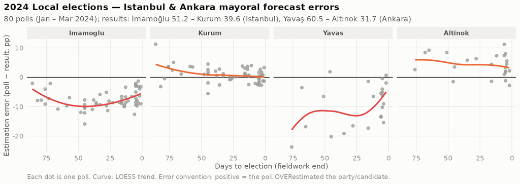

Putting the five races side by side makes the deeper point: the industry’s *collective* error is large, systematic within each race, and **unstable in direction across races**. Whatever generates it — differential turnout, late swing, herding, weighting choices — it is not a fixed partisan thumb on the scale, and it did not get smaller with experience. On the original study’s core question (“did forecasting improve?”) the 2023–24 answer is again **no**.

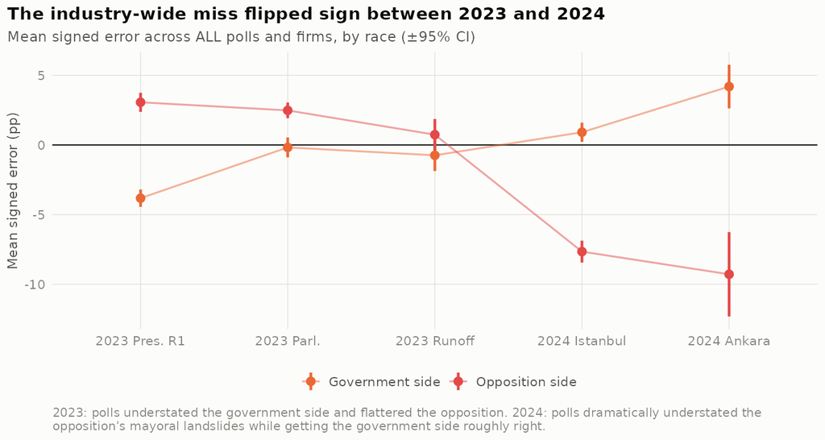

## House effects: who leans where

Because the whole industry misses together, a firm’s *raw* error mixes two things: the industry-wide miss and the firm’s own lean. To isolate the lean, each poll’s error is compared with the average error of **all other firms in the same race for the same party** (a leave-one-out relative error). A firm with a positive relative error on the government side systematically publishes friendlier numbers for Erdoğan/AKP than its peers, regardless of who the industry as a whole is wronging.

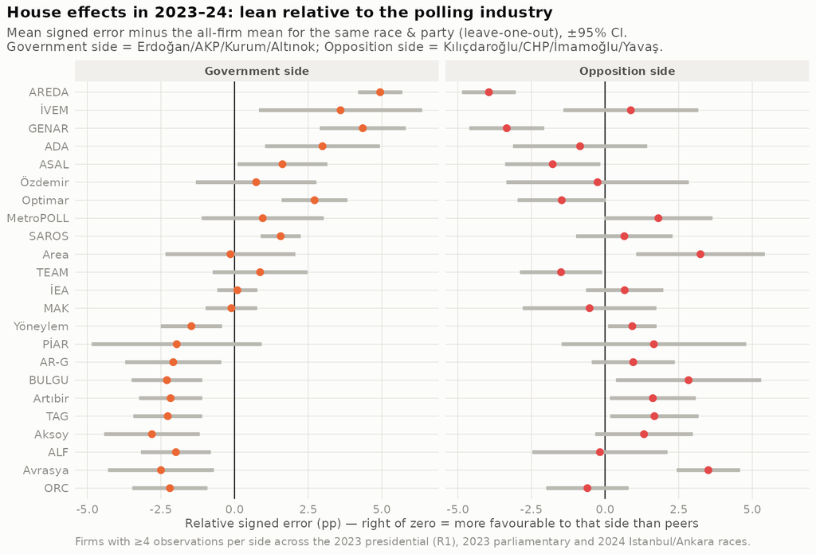

## The ORC and AKAM verdict

The original study’s headline suspicion can now be tested against three new national races — and the verdict is unexpected in both halves.

**ORC’s pro-AKP tilt did not survive.** The firm whose AKP estimates ran up to +10 points above the result in 2011–2019 underestimated Erdoğan by 6.5 points and AKP by 4.1 in 2023, and sat at the most government-*unfriendly* edge of the industry in relative terms (−2.2 on the government side). A house effect that flips sign between election cycles is hard to reconcile with a stable partisan bias; it looks more like methodology chasing the loudest narrative of each cycle.

**AKAM simply vanished from the record.** The firm the 2019 edition suspected of leaning CHP published no polls at all in Wikipedia’s 2023 campaign or 2024 mayoral lists (its last entries are 2021–22 hypothetical match-ups). Its founder remained a prominent commentator, but as a *forecaster* AKAM cannot be scored — a reminder that exit from the record is itself an outcome the original hypothesis never anticipated.

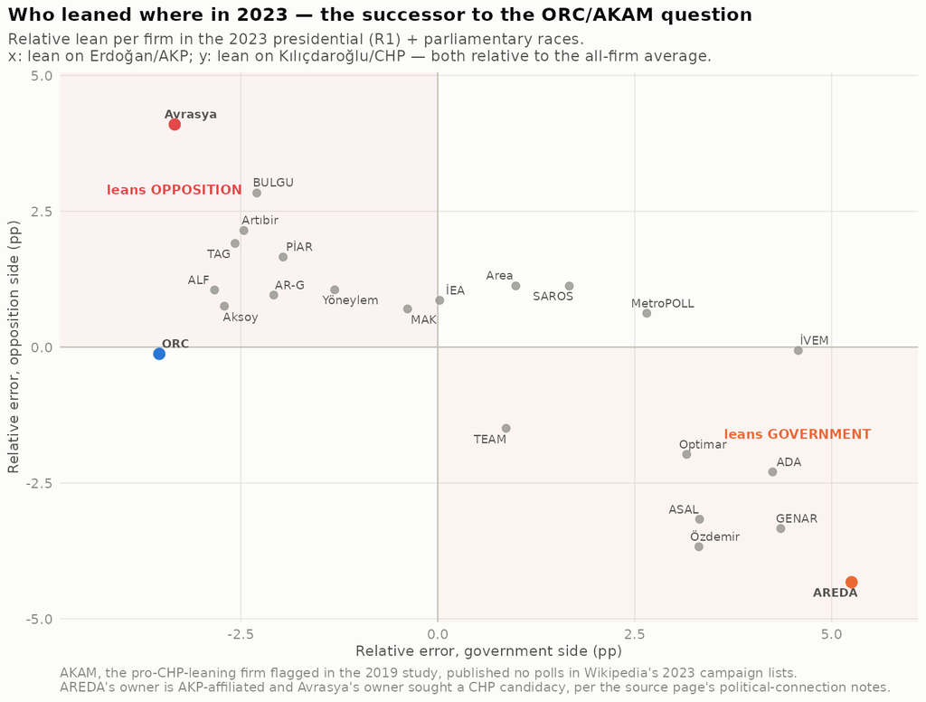

The deeper continuity with the 2019 edition is that **the phenomenon it described — mirrored, persistent, firm-specific leans — is alive and well; only the cast has changed.** Where the original pairing was ORC/AKAM, the 2023–24 pairing is AREDA/Avrasya, and this time the leans coincide with publicly documented political affiliations of the owners.

## Can anyone be trusted, then?

| Rank | Firm | Estimates | Races covered | Mean absolute error (pp) |
| --- | --- | --- | --- | --- |
| 1 | BETİMAR | 10 | 4 | 0.91 |
| 2 | Argetus | 11 | 2 | 1.46 |
| 3 | GENAR | 25 | 2 | 1.63 |
| 4 | İEA | 40 | 3 | 1.77 |
| 5 | ADA | 34 | 4 | 1.97 |
| 6 | KONDA | 14 | 4 | 2.02 |
| 7 | Özdemir | 35 | 5 | 2.10 |
| 8 | AREDA | 86 | 5 | 2.18 |
| 9 | TEAM | 22 | 2 | 2.30 |
| 10 | İVEM | 23 | 3 | 2.41 |
| 11 | Yöneylem | 59 | 3 | 2.44 |
| 12 | Optimar | 68 | 3 | 2.45 |
| 13 | Area | 35 | 5 | 2.63 |
| 14 | ASAL | 36 | 4 | 2.63 |
| 15 | Aksoy | 50 | 3 | 2.71 |
| 16 | BULGU | 31 | 2 | 2.74 |
| 17 | MetroPOLL | 32 | 3 | 2.95 |
| 18 | SAROS | 51 | 4 | 2.97 |
| 19 | AR-G | 34 | 2 | 2.99 |
| 20 | MAK | 44 | 4 | 3.01 |
| 21 | PİAR | 19 | 2 | 3.10 |
| 22 | SONAR | 19 | 3 | 3.13 |
| 23 | Remres | 16 | 2 | 3.14 |
| 24 | Artıbir | 30 | 3 | 3.32 |
| 25 | Sosyo Politik | 18 | 2 | 3.32 |
| 26 | TAG | 42 | 3 | 3.40 |
| 27 | Avrasya | 55 | 4 | 3.56 |
| 28 | ALF | 48 | 5 | 3.62 |
| 29 | ORC | 91 | 5 | 3.79 |
| 30 | TÜSİAR | 20 | 4 | 3.89 |
| 31 | Gezici | 19 | 3 | 3.94 |
| 32 | SER-AR | 17 | 3 | 4.10 |
| 33 | HBS | 32 | 4 | 5.20 |
| 34 | Themis | 12 | 2 | 5.24 |

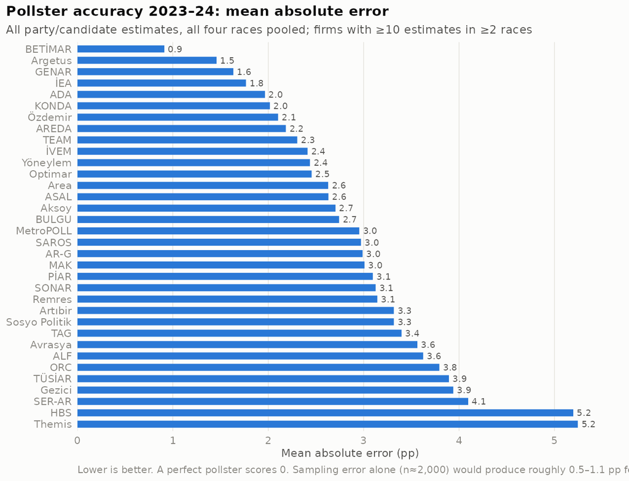

Two observations temper the ranking. First, the top of the table in 2023–24 is populated partly by firms whose *lean* happened to point against the industry’s miss (GENAR, ADA — government-leaning houses in a cycle when the industry under-called the government side). Being right for biased reasons is not a repeatable skill, and the 2024 mayoral races promptly punished several of them. Second, one genuine outlier deserves its name in print: **BETİMAR’s final polls were nearly exact in both presidential rounds** — all four first-round candidates within 0.43 points, and the runoff called at 52.2–47.8 against an actual 52.18–47.82. Its Istanbul and Ankara finals were also among the closest. Whether that survives another cycle is precisely the kind of question this study should revisit in 2028.

## Conclusions

The 2016/2019 study ended with a suspicion and a promise: the suspicion that some firms lean toward parties, and the promise that more elections would sharpen the picture. Three elections later the picture is sharper, but different in an instructive way.

On the industry level, the original finding stands and hardens: **Turkish election polling did not become more accurate between 2011 and 2024.** The average absolute error of a 2023 first-round presidential poll (about 4 points on each of the two main candidates, 3.5 pooled across all four) is of the same order as the errors of a decade earlier, and the 2024 mayoral polls missed by historic margins. The errors are collective and systematic within each race — polls do not merely scatter around the truth, they miss together — and the direction of the collective miss flipped from pro-opposition (2023) to pro-government (2024), which rules out the simplest partisan explanations and points instead at methodological herding and at persistent difficulty modelling turnout and late deciders.

On the firm level, the original ORC/AKAM hypothesis is **not confirmed in its specific form** — ORC’s lean inverted and AKAM left the stage — but its *structural* claim is confirmed in a stronger form than the original data allowed: firm-specific house effects of 3–5 points, stable across the 2023–24 races, mirrored between government- and opposition-friendly houses, and now traceable to documented owner affiliations (AREDA/Avrasya).

So, should we trust election polls? The Turkish record 2011–2024 suggests the honest answer is: *not any single poll, and not the raw average either.* In 2023 the average poll had Kılıçdaroğlu ahead by 2.2 points and he lost by 4.6 — a seven-point gap between the polled and the real margin. In 2024 the average poll had İmamoğlu ahead by 3 points and he won by 11.6, and had Yavaş ahead by 15 when he won by 29. On this record, single-digit polled margins say little about the winner and nothing about the scale. Reading polls with the firms’ house effects subtracted — as this update does — is the minimum diligence the data demand.

## Data & methods appendix

**Sources.** Poll tables were scraped from Wikipedia: [2023 presidential](https://en.wikipedia.org/wiki/Opinion_polling_for_the_2023_Turkish_presidential_election), [2023 parliamentary](https://en.wikipedia.org/wiki/Opinion_polling_for_the_2023_Turkish_parliamentary_election) and [2024 local elections](https://en.wikipedia.org/wiki/Opinion_polling_for_the_2024_Turkish_local_elections) (retrieved 8 July 2026). Official results from the corresponding Wikipedia results articles (YSK figures). The 2011–2019 figures are reproduced from the original edition of this study.

**Scope.** Campaign-period polls as listed by the source pages: 10 March – 13 May 2023 for the presidential first round; January – May 2023 for the parliamentary race; 15–28 May 2023 for the runoff (plus, shown separately, January–May hypothetical head-to-heads); January – March 2024 for Istanbul and Ankara. Nationwide party polls for the 2024 locals are not tabulated by the source page, so the 2024 analysis covers the two metropolitan races — the same two the original study analysed for 2019.

**Error convention.** Error = published poll share − official result share, in percentage points. Published values are used as-is, with two documented exceptions: (1) three first-round polls that left more than 5% of respondents unallocated were rescaled to the four-candidate total; (2) Istanbul polls reporting an explicit undecided share were rescaled to the decided electorate; runoff head-to-heads with undecideds were rescaled to the two-candidate vote.

**House effects.** A poll’s relative error is its error minus the mean error of all *other* firms’ polls for the same race and party (leave-one-out). Firm-side means, standard errors and 95% intervals are computed over these relative errors; firms with at least four observations per side are shown.

**Data quality.** Each scraped row carries internal redundancy (the published Lead column; alliance-total columns in the parliamentary table). All 340 polls were checked against these; five rows show arithmetic inconsistencies *on the source page itself* (e.g. a Lead that disagrees with the two shares it summarises) and were retained with their published shares. The full cleaned dataset (six CSV files), the scraping cache and all R code accompany this report and reproduce every figure and number.

**Caveats.** Wikipedia’s poll lists are curated and may omit unpublished or deleted polls (survivorship); AKAM’s absence is an absence *from the record*, not necessarily from activity. Firm identity was harmonised across spelling variants (e.g. “BETİMA”/“BETİMAR”, “Areda”/“AREDA Survey”). Sample-size information is too inconsistently reported to weight by, so all polls count equally, as in the original study.

*Original study: 2016, extended 2019. This edition: July 2026. Idea and inspiration: [Erol Taymaz, “Seçim Anketleri Ne Kadar Güvenilir?” (9 Nov 2015)](https://users.metu.edu.tr/etaymaz/secim-tahmin.html).*